# ProsperLoan Data Analysis

### by Pritesh Gujarati

## Investigation Overview

In this analysis I wanted to see which features are important for any Loan Applicant to get approval.My Main focus will be on some features like :'Term' , 'LoanStatus', 'BorrowerRate' , 'ProsperScore', 'EmploymentStatus', 'Occupation', 'BorrowerHomeowner','StatedMonthlyIncome', 'Recommendations', 'LoanOriginalAmount' , 'IncomeRange'.

## Dataset Overview

This ProsperLoan data set contains 113,937 loans with 81 variables on each loan. For this Project I have used few of the columns only for our analysis.

### What is the structure of your dataset?

> This data set have 113937 rows and 81 columns.columns like Term,Loan status ,loan amount and many more.

### What is/are the main feature(s) of interest in your dataset?

> I am interested in finding out which is the most effective feature that effect our load outcome.

### What features in the dataset do you think will help support your investigation into your feature(s) of interest?

> Loan status.

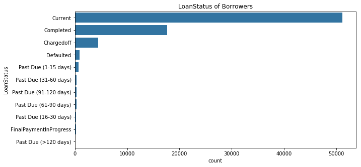

```python
#lets check for loanstatus.
plt.figure(figsize = [10, 5])
base_color = sb.color_palette()[0]
plt.title("LoanStatus of Borrowers")
sb.countplot(data = final_df, y = 'LoanStatus', color = base_color,
             order = final_df['LoanStatus'].value_counts().index);
```

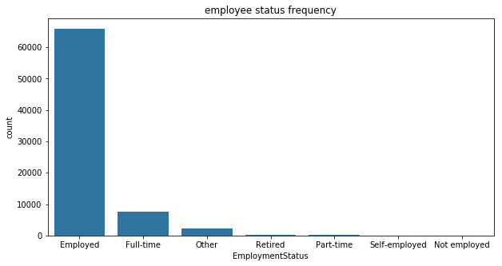

```python
#for employeestatus
plt.figure(figsize = [10,5])
base_color = sb.color_palette()[0]
plt.title('employee status frequency')
sb.countplot(data = final_df,x='EmploymentStatus',color=base_color,order=final_df['EmploymentStatus'].value_counts().index);
```

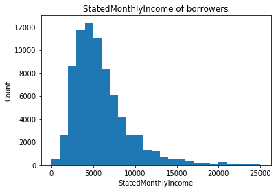

```python
final_df_2 = final_df[final_df['StatedMonthlyIncome'] <= 25000]
bin_edges = np.arange(0, final_df_2['StatedMonthlyIncome'].max()+1000, 1000)
plt.hist(data = final_df, x = 'StatedMonthlyIncome', bins = bin_edges);
plt.xlabel('StatedMonthlyIncome');
plt.ylabel('Count');
plt.title("StatedMonthlyIncome of borrowers");
```

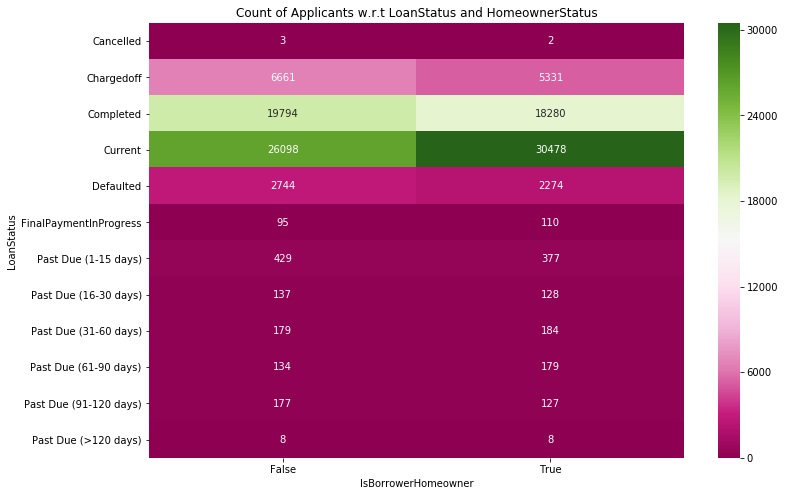

```python
plt.figure(figsize = [12, 8])
ct_counts = df.groupby(['IsBorrowerHomeowner', 'LoanStatus']).size()
ct_counts = ct_counts.reset_index(name = 'count')
ct_counts = ct_counts.pivot(index = 'LoanStatus', columns = 'IsBorrowerHomeowner', values = 'count')
sb.heatmap(ct_counts, annot = True, fmt = 'd',cmap="PiYG");
plt.title('Count of Applicants w.r.t LoanStatus and HomeownerStatus');
```

### Prosper rating dependent on Employment status and Income Range

- For all the high rating categries like AA, A, B, C the approval of loans are mostly depend on the applicants income range and Employment status

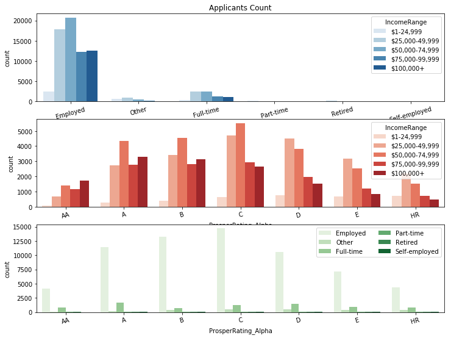

```python
categoric_vars = ['EmploymentStatus', 'ProsperRating_Alpha', 'IncomeRange']

plt.figure(figsize = [12, 9])

# subplot 1: EmployementStatus vs IncomeRange
plt.subplot(3, 1, 1)
sb.countplot(data = final_df_2, x = 'EmploymentStatus', hue = 'IncomeRange', palette = 'Blues')
plt.xticks(rotation = 15)
plt.title('Applicants Count')

# subplot 2: ProsperRating_Alpha vs IncomeRange
ax = plt.subplot(3, 1, 2)
sb.countplot(data = final_df_2, x = 'ProsperRating_Alpha', hue = 'IncomeRange', palette = 'Reds')

plt.xticks(rotation = 15)


# subplot 3: ProsperRating_Alpha vs EmploymentStatus
ax = plt.subplot(3, 1, 3)
sb.countplot(data = final_df_2, x = 'ProsperRating_Alpha', hue = 'EmploymentStatus', palette = 'Greens')
ax.legend(loc = 1, ncol = 2)
plt.xticks(rotation = 15)

plt.show()
```

### Applicants rating with monthly income and Employment Status

- Hight rating are given to the Employed and Full-time status applicants.

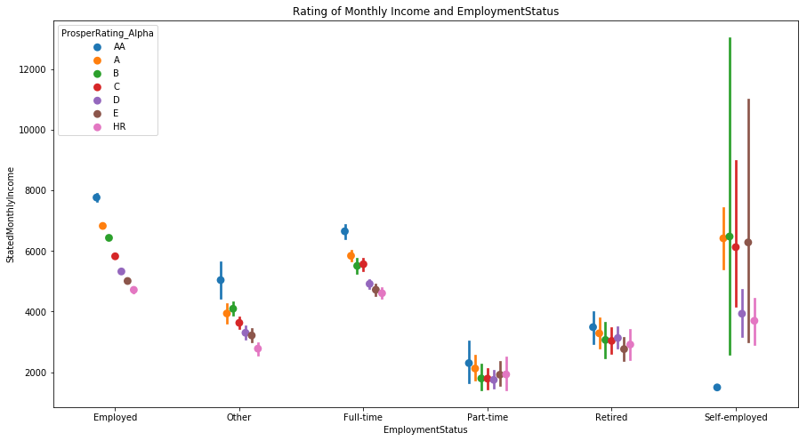

```python
#Does rating depend on the monhtly income and Employment status?
plt.figure(figsize = [15, 8])
ax = sb.pointplot(data = final_df_2, x = 'EmploymentStatus', y = 'StatedMonthlyIncome', hue = 'ProsperRating_Alpha',
                  dodge = 0.3, linestyles = "")
plt.title('Rating of Monthly Income and EmploymentStatus');
```

### Applicants rating with borrwers interest rate and homeowner status

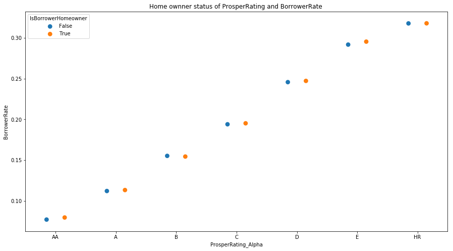

```python
#Did homeowner status has impacted the ProsperRating and Borrower Interest Rate?
plt.figure(figsize = [15, 8])
ax = sb.pointplot(data = final_df_2, x = 'ProsperRating_Alpha', y = 'BorrowerRate', hue = 'IsBorrowerHomeowner',
                  dodge = 0.3, linestyles = "");
plt.title('Home ownner status of ProsperRating and BorrowerRate ');
```